# 1. Quality control: which samples can we trust?

- Show All Code
- Hide All Code
- View Source

The first step in methylation analysis is quality control. A failed array, a swapped sample, or sex-mismatch can cause serious trouble downstream if it slips through. This notebook runs the standard `minfi` (Aryee et al. 2014) QC process on the 96-sample subset and walks you through how to decide what (if anything) to drop.

We start from the raw two-channel object saved at the end of the Setup step — `data/01_RGset.rds`.

```r
library(minfi)     # detectionP(), getQC(), getSex(), getSnpBeta()
library(ggplot2)   # every figure in this chapter

# The RGChannelSet written by the Setup chapter: raw red and green intensities
# for 1,051,943 addresses across 96 arrays.
rg <- readRDS("data/01_RGset.rds")

# Extract the phenotype table
ss <- as.data.frame(pData(rg))

rg
```

```
class: RGChannelSet
dim: 1051943 96
metadata(0):
assays(2): Green Red
rownames(1051943): 1600101 1600111 ... 99810990 99810992
rowData names(0):
colnames(96): GSM3853168 GSM3853169 ... GSM3853880 GSM3853881
colData names(18): sample_id series ... pc2 pc3
Annotation
  array: IlluminaHumanMethylationEPIC
  annotation: ilm10b4.hg19
```

The four checks below are independent of one another. Running all four takes under a minute.

## 1.1 Detection p-values — did the probe beat background?

Every probe is compared to the array’s negative-control distribution. A large **detection p-value** means the signal is indistinguishable from background; the measurement is noise. We summarize per sample: the mean detection p, and the fraction of probes failing at p > 0.01.

```r
# detectionP() compares every probe on every array against that array's own
# distribution of negative-control probes, and returns a probe x sample matrix
# of p-values.
detP <- detectionP(rg)

# Condense the detP into two summaries:
det_mean <- colMeans(detP)          # average detection p-value across all probes
det_fail <- colMeans(detP > 0.01)   # fraction of probes that failed the 0.01 cut

# One row per array, ready to plot.
det <- data.frame(sample    = colnames(rg),
                  mean_detP = as.numeric(det_mean),
                  frac_fail = as.numeric(det_fail),
                  slide     = ss$slide)
head(det, 3)
```

|  | sample | mean_detP | frac_fail | slide |
| --- | --- | --- | --- | --- |
| 1 | GSM3853168 | 0.0001635365 | 0.0005945248 | 200932680028 |
| 2 | GSM3853169 | 0.0001808356 | 0.0005748997 | 200932680028 |
| 3 | GSM3853170 | 0.0001705915 | 0.0005760542 | 200932680028 |

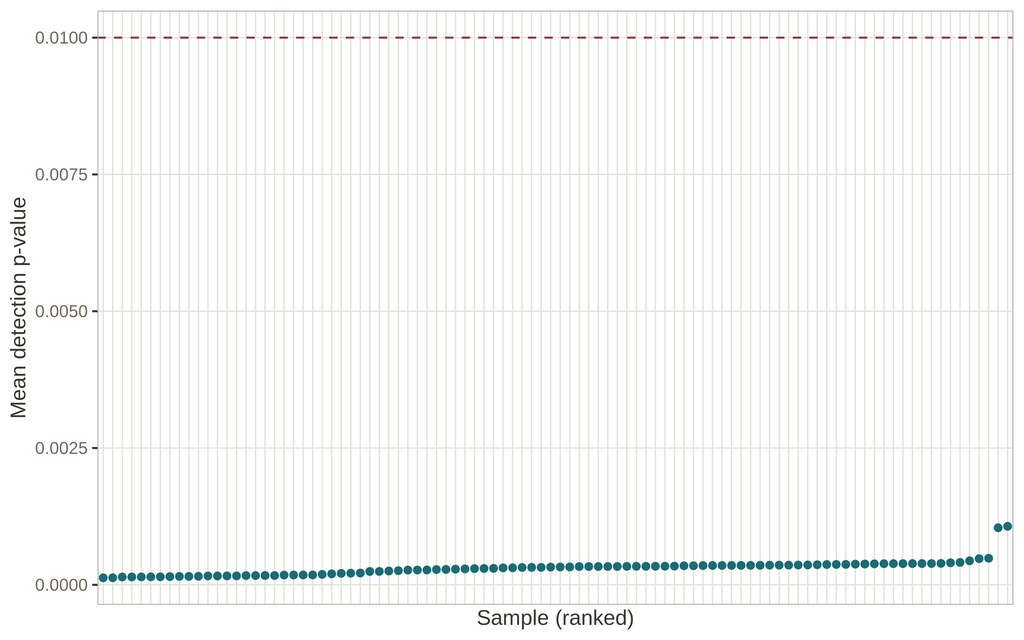

Figure 1.1: Per-sample detection p-value. All 96 samples have a detection p-value below 0.01, passing this QC check.

```r
ggplot(det, aes(x = reorder(sample, mean_detP), y = mean_detP)) +
  geom_point(color = "#1A6B75", size = 1.6) +                                  # teal
  geom_hline(yintercept = 0.01, linetype = "dashed", color = "#8C3A4A") +      # plum
  labs(x = "Sample (ranked)", y = "Mean detection p-value") +
  theme(axis.text.x = element_blank(), axis.ticks.x = element_blank())
```

```r
cat("worst sample mean detP:", signif(max(det$mean_detP), 3), "\n")
```

```
worst sample mean detP: 0.00107
```

```r
cat("worst sample % probes p>0.01:", signif(max(det$frac_fail) * 100, 3), "%\n")
```

```
worst sample % probes p>0.01: 0.598 %
```

```r
cat("samples failing QC (mean detP > 0.01):", sum(det$mean_detP > 0.01), "\n")
```

```
samples failing QC (mean detP > 0.01): 0
```

**NoteWhat a failure would look like**

On a real plate you will sometimes see one or two samples an order of magnitude above the rest, crossing the 0.01 line. Those get dropped before normalization.

## 1.2 Signal intensity — is the array bright enough?

`getQC()` reduces each sample to the median methylated (`mMed`) and unmethylated (`uMed`) log2 intensity. Weak arrays fall toward the bottom-left; `minfi`’s convention flags samples below a line at `(mMed + uMed)/2 = 10.5`.

```r
# getQC() needs the two channels separated into methylated and unmethylated
# signal, which is what preprocessRaw() does.
mset  <- preprocessRaw(rg)
qc_df <- getQC(mset)           # one row per sample: mMed and uMed

qc <- as.data.frame(qc_df)
qc$sample <- rownames(qc)
# minfi's convention: flag an array whose two medians average below 10.5.
qc$flag <- ((qc$mMed + qc$uMed) / 2) < 10.5
head(qc, 3)
```

|  | mMed | uMed | sample | flag |
| --- | --- | --- | --- | --- |
| GSM3853168 | 11.93111 | 11.05934 | GSM3853168 | FALSE |
| GSM3853169 | 12.05664 | 11.13507 | GSM3853169 | FALSE |
| GSM3853170 | 12.07381 | 11.04712 | GSM3853170 | FALSE |

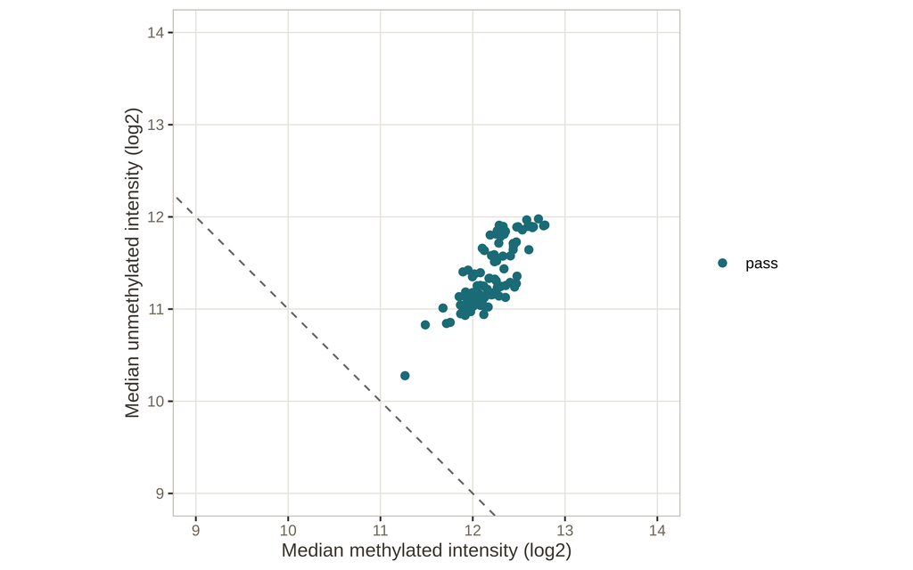

Figure 1.2: Median methylated vs unmethylated log2 intensity. All samples are above the low-signal threshold, passing this QC check.

```r
ggplot(qc, aes(mMed, uMed, color = flag)) +
  geom_point(size = 2) +
  geom_abline(intercept = 2 * 10.5, slope = -1, linetype = "dashed", color = "gray40") +
  scale_color_manual(values = c(`FALSE` = "#1A6B75", `TRUE` = "#8C3A4A"),
                     labels = c("pass", "low signal"), name = NULL) +
  labs(x = "Median methylated intensity (log2)",
       y = "Median unmethylated intensity (log2)") +
  coord_equal(xlim = c(9, 14), ylim = c(9, 14))
```

```r
cat("mMed range:", round(min(qc$mMed),2), "-", round(max(qc$mMed),2), "\n")
```

```
mMed range: 11.27 - 12.78
```

```r
cat("low-signal flagged samples:", sum(qc$flag), "\n")
```

```
low-signal flagged samples: 0
```

## 1.3 Predicted vs reported sex

Sex is the single most reliable phenotype to predict from methylation: the X and Y chromosome signal is unambiguous. `getSex()` compares median total intensity on X vs Y. A mismatch between predicted and reported sex is a strong signal of a **sample swap or annotation error** — and, because sex is a strong methylation covariate we must model, catching it here is important.

```r
# getSex() works on median intensity per chromosome, so the probes need to be
# mapped to coordinates on the genome first. mapToGenome() attaches those coordinates
# using the EPIC annotation package.
gmset <- mapToGenome(mset)
psex  <- getSex(gmset)         # xMed, yMed and predictedSex per sample

sx <- data.frame(sample    = colnames(rg),
                 xMed      = psex$xMed,
                 yMed      = psex$yMed,
                 predicted = as.character(psex$predictedSex),
                 reported  = as.character(ss$sex))   # reported sex from the sample sheet
sx$mismatch <- sx$predicted != sx$reported
head(sx, 3)
```

|  | sample | xMed | yMed | predicted | reported | mismatch |
| --- | --- | --- | --- | --- | --- | --- |
| GSM3853168 | GSM3853168 | 12.38990 | 12.67970 | M | M | FALSE |
| GSM3853169 | GSM3853169 | 12.44592 | 12.65531 | M | M | FALSE |
| GSM3853170 | GSM3853170 | 12.45186 | 12.74882 | M | M | FALSE |

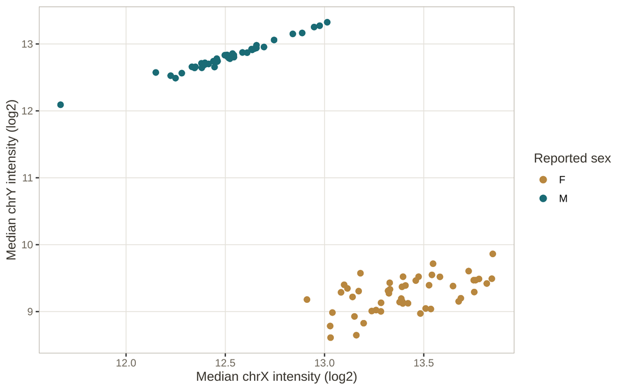

Figure 1.3: Predicted sex from X/Y intensity, colored by reported sex. Clean separation, zero mismatches.

```r
ggplot(sx, aes(xMed, yMed, color = reported, shape = mismatch)) +
  geom_point(size = 2.5) +
  scale_color_manual(values = c(F = "#B8873F", M = "#1A6B75"), name = "Reported sex") +
  scale_shape_manual(values = c(`FALSE` = 16, `TRUE` = 4), guide = "none") +
  labs(x = "Median chrX intensity (log2)", y = "Median chrY intensity (log2)")
```

```r
tab <- table(reported = sx$reported, predicted = sx$predicted)
knitr::kable(tab, caption = "Reported vs predicted sex")
```

Reported vs predicted sex

|  | F | M |
| --- | --- | --- |
| F | 49 | 0 |
| M | 0 | 47 |

```r
cat("sex mismatches:", sum(sx$mismatch), "of", nrow(sx), "\n")
```

```
sex mismatches: 0 of 96
```

## 1.4 SNP-identity fingerprint

EPIC carries ~59 `rs` SNP probes that measure genotype, not methylation. Their beta values cluster near 0, 0.5, or 1 (the three genotypes). They are useful for two things: spotting **sample duplicates / swaps** (two arrays from the same person share a fingerprint) and, in longitudinal designs, confirming that repeat samples really are the same individual.

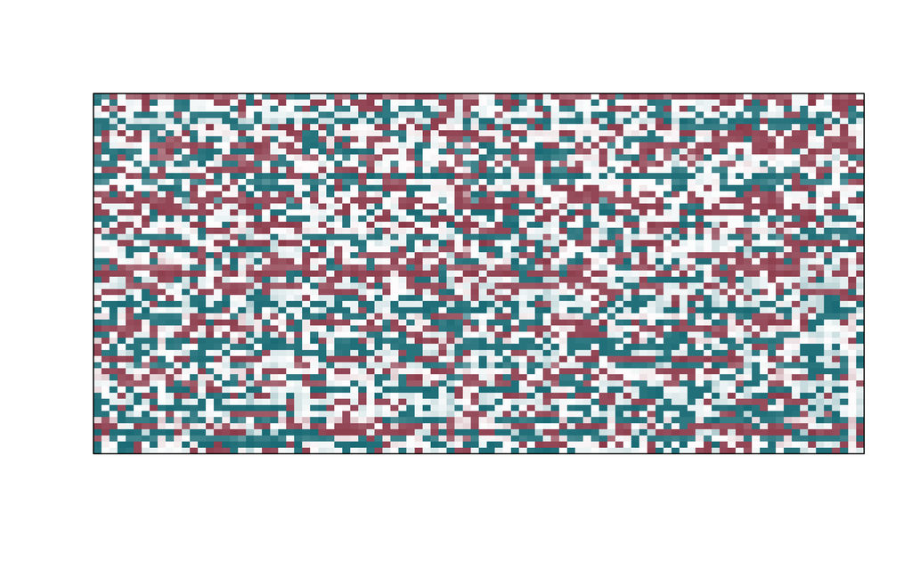

Figure 1.4: The ~59 rs SNP probes across samples, with samples ordered by hierarchical clustering of their fingerprints. Discrete banding near 0 / 0.5 / 1 is the expected genotype signal; no two columns are identical, so no duplicate samples.

```r
# getSnpBeta() pulls just the rs probes out of the raw object and returns their
# beta values.
snps <- getSnpBeta(rg)

# Cluster the samples by 'fingerprint' so that any identical pair would sit
# side by side in the figure below.
d   <- dist(t(snps))
ord <- hclust(d)$order
image(t(snps[, ord]), col = colorRampPalette(c("#1A6B75", "white", "#8C3A4A"))(64),
      axes = FALSE)
box()
```

```r
# nearest-neighbor distance: a near-zero value would flag a duplicate
dm <- as.matrix(dist(t(snps)))
diag(dm) <- NA
nn <- apply(dm, 1, min, na.rm = TRUE)
cat("SNP probes:", nrow(snps), "\n")
```

```
SNP probes: 59
```

```r
cat("smallest between-sample fingerprint distance:", round(min(nn), 3),
    "(a value near 0 would indicate a duplicate)\n")
```

```
smallest between-sample fingerprint distance: 2.224 (a value near 0 would indicate a duplicate)
```

## 1.5 Verdict

```r
# Each check contributes a list of sample IDs to drop.
drop_detp <- det$sample[det$mean_detP > 0.01]
drop_int  <- qc$sample[qc$flag]
drop_sex  <- sx$sample[sx$mismatch]     # sample IDs, to investigate rather than drop

# Only the first two are automatic. A sex mismatch signal needs to be checked before
# dropping.
keep <- setdiff(colnames(rg), unique(c(drop_detp, drop_int)))

cat("Samples in:", ncol(rg), "\n")
```

```
Samples in: 96
```

```r
cat("Dropped for detection p:", length(drop_detp), "\n")
```

```
Dropped for detection p: 0
```

```r
cat("Dropped for low intensity:", length(drop_int), "\n")
```

```
Dropped for low intensity: 0
```

```r
cat("Sex mismatches (investigate, don't auto-drop):", length(drop_sex), "\n")
```

```
Sex mismatches (investigate, don't auto-drop): 0
```

```r
cat("Samples passing QC:", length(keep), "\n")
```

```
Samples passing QC: 96
```

All 96 samples pass. We carry the full set forward to normalization.

Note that “96 samples pass QC” is not the same as “96 samples are analyzed”. Nine of them have no recorded PTSD status and will drop out when the exposure enters the model — see phenotype completeness in Section 1.7.

**TipAlways do QC. ALWAYS**

Even though all samples passed QC thresholds in this subset, doing the QC was still important as now we have evidence supporting that these samples are ‘clean’. In a real dataset there are typically several samples that will not pass QC for one of the 4 checks.

## 1.6 Saving what we just computed

We export two files from this section:

```r
# 1. The full set of pieces, exactly as deposited in the Zenodo record. Keeping
#    the S4 objects (`qc` and `psex` are DFrames) means the saved file is the
#    same object the code above produced, with nothing coerced or rounded.
qc_pieces <- list(
  det_mean = det_mean,                 # named numeric, one per sample
  det_fail = det_fail,                 # named numeric, one per sample
  qc       = qc_df,                    # DFrame: mMed, uMed
  psex     = psex,                     # DFrame: xMed, yMed, predictedSex
  rep_sex  = as.character(ss$sex),     # reported sex, from the sample sheet
  snps     = snps                      # 59 rs probes x 96 samples
)
saveRDS(qc_pieces, "data/01_qc_pieces.rds")

# 2. A flat, standard-delimited, per-sample table of the same measurements.
qc_metrics <- data.frame(
  sample         = colnames(rg),
  mean_detP      = as.numeric(det_mean),
  frac_detP_fail = as.numeric(det_fail),
  mMed           = as.numeric(qc_df$mMed),
  uMed           = as.numeric(qc_df$uMed),
  xMed           = as.numeric(psex$xMed),
  yMed           = as.numeric(psex$yMed),
  predicted_sex  = as.character(psex$predictedSex),
  reported_sex   = as.character(ss$sex),
  slide          = ss$slide,
  array_pos      = ss$array_pos,
  qc_pass        = colnames(rg) %in% keep,
  stringsAsFactors = FALSE)

write.table(qc_metrics, "data/01_qc_sample_metrics.tsv",
            sep = "\t", row.names = FALSE, quote = FALSE)
```

**NotePicking the chapter up from the saved table instead**

If reading the IDATs or holding the raw object in memory is not practical on your machine, you can skip straight to the figures. The per-sample table is in the repository, so it can be read directly over the network — no clone and no download step:

```
RStudio Console
```

```r
library(data.table)
qc_metrics <- fread(paste0("https://raw.githubusercontent.com/krferrier/",
                           "Methylation-EWAS-tutorial/main/tutorial/data/",
                           "01_qc_sample_metrics.tsv"))

# The plotting frames used above, rebuilt from the table:
det <- data.frame(sample = qc_metrics$sample, mean_detP = qc_metrics$mean_detP,
                  frac_fail = qc_metrics$frac_detP_fail, slide = qc_metrics$slide)
qc  <- data.frame(sample = qc_metrics$sample, mMed = qc_metrics$mMed,
                  uMed = qc_metrics$uMed)
qc$flag <- ((qc$mMed + qc$uMed) / 2) < 10.5
sx  <- data.frame(sample = qc_metrics$sample, xMed = qc_metrics$xMed,
                  yMed = qc_metrics$yMed, predicted = qc_metrics$predicted_sex,
                  reported = qc_metrics$reported_sex)
sx$mismatch <- sx$predicted != sx$reported
```

With this data you can run the detection-*p*, intensity and sex-check figures and tables. The SNP heatmap and duplicate check need the 59 x 96 genotype matrix rather than a per-sample summary, and the other parts need the `RGChannelSet` itself. You won’t be able to rerun the checks without the unprocessed individual-level data.

## 1.7 Missing phenotypes

QC checks whether the *arrays* worked. It is also the right time to check whether the **phenotype data** you will eventually model is complete.

There are two distinct kinds of gap: a variable that is **absent for every sample**; a variable that is **present but incomplete**. A variable that is missing from every sample can potentially cause unmeasured confounding that biases the results of your analysis. If you know beforehand you are missing an important variable that could confound your analysis, you can attempt to create a suitable proxy or surrogate variable. If a variable is present, but missing from a few individuals, then these samples are excluded from analyses.

### Missing values in the variables we intend to model

Tabulate missingness for every term in the planned model, before you normalize:

```r
model_vars <- c("ptsd", "sex", "age", "pc1", "pc2", "pc3",
                "mergedcapsandpsswinthin30days")
miss <- data.frame(
  variable = model_vars,
  n_missing = sapply(model_vars, function(v)
    sum(is.na(ss[[v]]) | ss[[v]] == "")),
  row.names = NULL)
knitr::kable(miss, caption = "Missing values per candidate model variable, across all 96 QC-passing arrays.")
```

Missing values per candidate model variable, across all 96 QC-passing arrays.

| variable | n_missing |
| --- | --- |
| ptsd | 9 |
| sex | 0 |
| age | 0 |
| pc1 | 1 |
| pc2 | 1 |
| pc3 | 1 |
| mergedcapsandpsswinthin30days | 9 |

PTSD status — the exposure — is missing for 9 of the 96 samples. The raw CAPS/PSS indicator (`mergedcapsandpsswinthin30days`), which `ptsd` is derived from, is missing for the same samples, as expected. The three genetic ancestry PCs are missing for one additional sample.

**ImportantThese ten samples are dropped later, and it is not a QC failure**

All samples passed the standard QC checks based on the methylation data. But association testing requires complete data for the phenotypes needed in the model (exposure of interest and any other covariates). `lm` / `limma` will drop any sample with no PTSD status — the analysis in chapter 7 and the pipeline run in chapter 8 therefore fit **n = 86**, not 96: nine samples have no PTSD status, and one more has no genetic ancestry PCs (Genetic ancestry PCs).

This tutorial keeps all 96 samples through normalization (chapter 2), probe filtering (chapter 3), and cell-composition estimation (chapter 4) on purpose. None of those steps uses PTSD status: they describe the arrays, not the association model, so there is no reason to discard usable data before the step that actually needs the exposure. The count changes in batch effects, because the batch correction and surrogate variables there are estimated with the exposure and the genetic PCs in the model.

The distinction worth internalising: **samples dropped for quality** are samples you do not trust, and **samples dropped for missing phenotype** are samples you trust but cannot model. Report them separately.

Because the nine without PTSD status are a loss from missingness rather than quality, it is important to check whether they are **missing at random** or missing in a way that correlates with something. If the samples without PTSD status were, say, all male or all from one chip, dropping them would distort the design:

```r
no_ptsd <- is.na(ss$ptsd) | ss$ptsd == ""
cat("samples with no PTSD status:", sum(no_ptsd), "\n")
```

```
samples with no PTSD status: 9
```

```r
cat("sex:", paste(names(table(ss$sex[no_ptsd])),
                 table(ss$sex[no_ptsd]), collapse = " / "), "\n")
```

```
sex: F 4 / M 5
```

```r
cat("age range:", paste(range(ss$age[no_ptsd]), collapse = "-"), "\n")
```

```
age range: 22-65
```

```r
cat("distinct chips:", length(unique(ss$slide[no_ptsd])),
    "of", length(unique(ss$slide)), "\n")
```

```
distinct chips: 8 of 12
```

Four female and five male, ages spanning the full cohort range, spread across eight of the twelve chips — the missingness looks incidental rather than structured. If the missingness appears structured, you would need to consider an alternative analysis plan to what is described in this tutorial that is appropriate for structured missingness.

### Variables absent for every sample

For blood methylation the most consequential gap is usually **smoking**. Smoking produces some of the largest and most reproducible methylation signals in blood (Joehanes et al. 2016), so an unmeasured smoking variable is unmeasured confounding. The Grady deposit gives PTSD, age, sex, race, and childhood trauma — but no smoking variable, which is common in public deposits.

That absence is worth noting because it shapes decisions in chapters 6 and 7: batch effects builds a methylation-based smoking proxy. The full set of options, and the one this tutorial takes, is laid out in the EWAS chapter.

**TipInventory your covariates before you normalize**

Write down the model you intend to fit, then check each term against the metadata you actually have. For each term ask two questions: *is it present at all?* and *how many samples is it missing for?* The first tells you what you cannot adjust for; the second tells you your real analysis n. Note both, and decide *then* how you will handle them — including whether a term is worth the samples it costs.

## References

Aryee, Martin J, Andrew E Jaffe, Hector Corrada-Bravo, et al. 2014. “Minfi: A Flexible and Comprehensive Bioconductor Package for the Analysis of Infinium DNA Methylation Microarrays.” *Bioinformatics* 30 (10): 1363–69. https://doi.org/10.1093/bioinformatics/btu049.

Joehanes, Roby, Allan C Just, Riccardo E Marioni, et al. 2016. “Epigenetic Signatures of Cigarette Smoking.” *Circulation: Cardiovascular Genetics* 9 (5): 436–47. https://doi.org/10.1161/CIRCGENETICS.116.001506.